# S-Mobile: Customer Churn Prediction & Retention Profit

Deepa Das

# Preliminaries

### Determine notebook defaults:

### Load packages:

### Read in the data:

```r
# use load("../data/smobile_churn.Rdata") for .Rdata files

load("../data/smobile_churn.Rdata")
```

# Assignment answers

## 1.Develop a model to predict customer churn using the smobile dataset

```r
smobile$churn <- factor(smobile$churn)
# Split into training and test sets
train_data <- smobile %>% filter(training == 1)
test_data  <- smobile %>% filter(training == 0)

# Check class balance
table(train_data$churn)
```

```
   0    1
6724  276
```

```r
# Remove unnecessary variables
train_data_clean <- train_data %>% select(-customer, -training)
test_data_clean  <- test_data %>% select(-customer, -training)

# Fit logistic regression
model_logit <- glm(churn ~ ., data = train_data_clean, family = "binomial")

# Summarize coefficients
summary(model_logit)
```

```
Call:
glm(formula = churn ~ ., family = "binomial", data = train_data_clean)

Coefficients:
              Estimate Std. Error z value Pr(>|z|)
(Intercept) -3.0790100  0.3927087  -7.840 4.49e-15 ***
revenue      0.0023081  0.0026485   0.871 0.383512
mou         -0.0005223  0.0002282  -2.289 0.022082 *
overage      0.0012991  0.0008707   1.492 0.135689
roam         0.0011300  0.0091256   0.124 0.901454
changem     -0.0001456  0.0003150  -0.462 0.644007
changer     -0.0011700  0.0020578  -0.569 0.569664
dropvce      0.0003786  0.0088781   0.043 0.965982
blckvce      0.0157017  0.0039198   4.006 6.18e-05 ***
unansvce     0.0013042  0.0021420   0.609 0.542628
custcare    -0.0059974  0.0168837  -0.355 0.722428
threeway    -0.0233032  0.0328647  -0.709 0.478284
months      -0.0181096  0.0107572  -1.683 0.092281 .
uniqsubs     0.1638001  0.0636055   2.575 0.010017 *
phones       0.0311120  0.0708582   0.439 0.660607
eqpdays      0.0013142  0.0003807   3.452 0.000557 ***
age         -0.0162599  0.0068316  -2.380 0.017308 *
children1   -0.0434708  0.1643164  -0.265 0.791352
creditaa1   -0.5547280  0.2264624  -2.450 0.014304 *
refurb1      0.0265338  0.1917298   0.138 0.889931
occprof1     0.2074751  0.1891593   1.097 0.272717
occcler1    -0.0641170  0.5219908  -0.123 0.902240
occcrft1     0.5967373  0.3194304   1.868 0.061744 .
occstud1     0.2242857  0.7366422   0.304 0.760770
occhmkr1     0.8009078  0.7505756   1.067 0.285946
occret1      0.1974465  0.6198244   0.319 0.750066
occself1     0.3147290  0.4757480   0.662 0.508262
travel1     -0.1672166  0.3064518  -0.546 0.585304
retcalls     0.4969203  0.2733701   1.818 0.069101 .
refer       -0.5650638  0.3783102  -1.494 0.135267
incmiss1     0.1611407  0.3196411   0.504 0.614170
income      -0.0122394  0.0354409  -0.345 0.729833
mcycle1     -0.1849379  0.5972747  -0.310 0.756838
agemiss1    -0.4348835  0.3683478  -1.181 0.237749
---
Signif. codes:  0 '***' 0.001 '**' 0.01 '*' 0.05 '.' 0.1 ' ' 1

(Dispersion parameter for binomial family taken to be 1)

    Null deviance: 2325.7  on 6999  degrees of freedom
Residual deviance: 2245.4  on 6966  degrees of freedom
AIC: 2313.4

Number of Fisher Scoring iterations: 6
```

## Question 2: Use the model to understand the main drivers of churn

```r
## Tidy Summary of Model
logit_summary <- tidy(model_logit)
logit_summary
```

```
# A tibble: 34 × 5
   term         estimate std.error statistic  p.value
   <chr>           <dbl>     <dbl>     <dbl>    <dbl>
 1 (Intercept) -3.08      0.393      -7.84   4.49e-15
 2 revenue      0.00231   0.00265     0.871  3.84e- 1
 3 mou         -0.000522  0.000228   -2.29   2.21e- 2
 4 overage      0.00130   0.000871    1.49   1.36e- 1
 5 roam         0.00113   0.00913     0.124  9.01e- 1
 6 changem     -0.000146  0.000315   -0.462  6.44e- 1
 7 changer     -0.00117   0.00206    -0.569  5.70e- 1
 8 dropvce      0.000379  0.00888     0.0426 9.66e- 1
 9 blckvce      0.0157    0.00392     4.01   6.18e- 5
10 unansvce     0.00130   0.00214     0.609  5.43e- 1
# ℹ 24 more rows
```

```r
## Filter for Significant Variables

significant_vars <- logit_summary %>%
  filter(p.value < 0.05, term != "(Intercept)")

## Rank by Importance

top_drivers <- significant_vars %>%
  arrange(desc(abs(estimate)))

## View and Print Top Drivers
print(head(top_drivers, 10))
```

```
# A tibble: 6 × 5
  term       estimate std.error statistic   p.value
  <chr>         <dbl>     <dbl>     <dbl>     <dbl>
1 creditaa1 -0.555     0.226        -2.45 0.0143
2 uniqsubs   0.164     0.0636        2.58 0.0100
3 age       -0.0163    0.00683      -2.38 0.0173
4 blckvce    0.0157    0.00392       4.01 0.0000618
5 eqpdays    0.00131   0.000381      3.45 0.000557
6 mou       -0.000522  0.000228     -2.29 0.0221
```

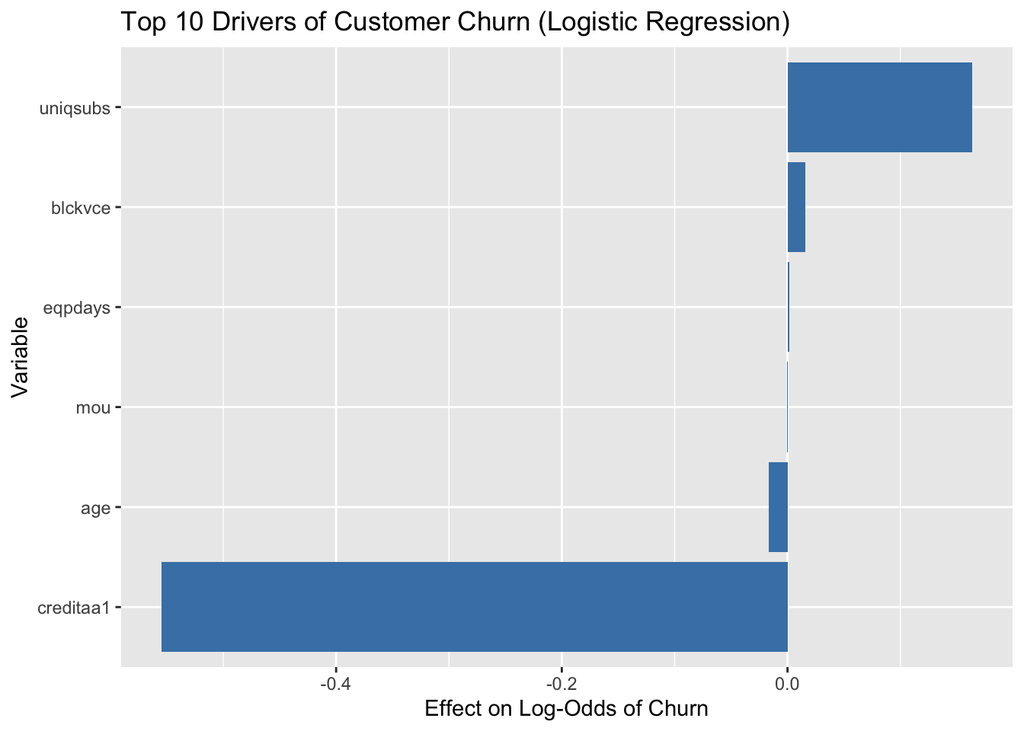

```r
## Visualize
top_drivers %>%
  slice_max(order_by = abs(estimate), n = 10) %>%
  ggplot(aes(x = reorder(term, estimate), y = estimate)) +
  geom_col(fill = "steelblue") +
  coord_flip() +
  labs(
    title = "Top 10 Drivers of Customer Churn (Logistic Regression)",
    x = "Variable",
    y = "Effect on Log-Odds of Churn"
  )
```

```r
kable(head(top_drivers, 10), digits = 3)
```

| term | estimate | std.error | statistic | p.value |
| --- | --- | --- | --- | --- |
| creditaa1 | -0.555 | 0.226 | -2.450 | 0.014 |
| uniqsubs | 0.164 | 0.064 | 2.575 | 0.010 |
| age | -0.016 | 0.007 | -2.380 | 0.017 |
| blckvce | 0.016 | 0.004 | 4.006 | 0.000 |
| eqpdays | 0.001 | 0.000 | 3.452 | 0.001 |
| mou | -0.001 | 0.000 | -2.289 | 0.022 |

## Customers with a high credit rating (e.g., creditaa1) are significantly less likely to churn, indicating that financial reliability is linked to customer retention. In contrast, those who experience blocked voice calls (blckvce) or who use older equipment (eqpdays) exhibit a higher risk of churn, likely due to dissatisfaction with service reliability or outdated technology. Additionally, a higher number of unique household subscribers (uniqsubs) is associated with increased churn risk, potentially reflecting shared plans with lower individual commitment. On the other hand, older customers (age) and those with higher average monthly usage (mou) demonstrate greater loyalty, likely due to established habits and perceived value from the service.

## Question 3: Use insights to develop actions/offers/incentives

```r
##Based on the logistic regression model, we identified the top drivers of churn. These include:


##Blocked voice attempts (blckvce)
##uniqsubs
##Mou
##Device age (eqpdays)
##Credit rating (creditaa1)
##We now design actions and incentives that directly address each of these drivers.
```

## Action 1: Upgrade Aging Devices

##Driver: Customers with older devices (eqpdays) are more likely to churn. ##Incentive: Offer free or subsidized handset upgrades to customers whose devices are more than 2 years old. ##Target Segment: Customers with eqpdays > 700 ##Rationale: A modern device improves the experience, reduces tech-related complaints, and makes users less likely to switch carriers.

##Action 2: Reduce Call Frustration ##Driver: High levels of blocked calls (blckvce) strongly predict churn. ##Incentive: Provide a monthly service credit (e.g., $10) for customers with poor call quality. ##Target Segment: Customers with blckvce > 1 ##Rationale: Signals that the company acknowledges the issue and is investing in network improvements, which can rebuild trust.

##Action 3: Boost Engagement with Bonus Minutes ##Driver:Low engagement, as measured by low minutes of use (MOU), is correlated with higher churn rates. ##These users may not yet be fully invested in the service, making them more likely to leave. ##Incentive: Offer 10% bonus minutes to customers with below-median usage. This can take the form of free ##talk time or data rollovers for a limited period. ##Target Segment:Customers with MOU less than or equal to median and in the top 40% churn risk (e.g., prob_churn >= 60th percentile), ##as they are both vulnerable and under-engaged. ##Rationale:This action increases switching costs by encouraging customers to use the service more, deepening their reliance on the platform. More usage also improves customer experience and can lead to stronger retention through habit formation.

## Question 4: Estimate the impact of these actions/offers/incentives on the probability of churn in the rollout dataset

```r
# --- STEP 1: Predict Baseline Churn ---
rollout$pred_churn_base <- predict(model_logit, newdata = rollout, type = "response")

# Define high-risk threshold (top 40%)
risk_threshold <- quantile(rollout$pred_churn_base, 0.60, na.rm = TRUE)

# --- STEP 2: Simulate Action 1 – Device Upgrade ---
rollout$target_device_upgrade <- rollout$eqpdays >= 720 & rollout$pred_churn_base >= risk_threshold

rollout_upgraded <- rollout
rollout_upgraded$eqpdays <- ifelse(rollout$target_device_upgrade, 30, rollout$eqpdays)
rollout_upgraded$pred_churn_after_upgrade <- predict(model_logit, newdata = rollout_upgraded, type = "response")

# --- STEP 3: Simulate Action 2 – Network Quality Fix ---
rollout$target_network_fix <- rollout$blckvce > 1

rollout_better_network <- rollout
rollout_better_network$blckvce <- ifelse(rollout$target_network_fix, 0, rollout$blckvce)

rollout_better_network$pred_churn_after_network_fix <- predict(model_logit, newdata = rollout_better_network, type = "response")

# --- STEP 4: Simulate Action 3 – Bonus Minutes ---
mou_median <- median(rollout$mou, na.rm = TRUE)
rollout$target_bonus_minutes <- rollout$mou <= mou_median & rollout$pred_churn_base >= risk_threshold

rollout_bonus <- rollout
rollout_bonus$mou <- ifelse(rollout$target_bonus_minutes, rollout$mou * 1.10, rollout$mou)
rollout_bonus$pred_churn_after_bonus <- predict(model_logit, newdata = rollout_bonus, type = "response")

# --- STEP 5: Compare Churn Among Targeted ---
mean(rollout$pred_churn_base)  # For reference
```

```
[1] 0.03934331
```

```r
mean(rollout_upgraded$pred_churn_after_upgrade[rollout$target_device_upgrade])
```

```
[1] 0.02134942
```

```r
mean(rollout_better_network$pred_churn_after_network_fix[rollout$target_network_fix])
```

```
[1] 0.03424704
```

```r
mean(rollout_bonus$pred_churn_after_bonus[rollout$target_bonus_minutes])
```

```
[1] 0.05728058
```

```r
# Expected output format
cat("Baseline churn rate (entire rollout):", round(mean(rollout$pred_churn_base), 5), "\n")
```

```
Baseline churn rate (entire rollout): 0.03934
```

```r
cat("Churn after device upgrade (targeted):",
    round(mean(rollout_upgraded$pred_churn_after_upgrade[rollout$target_device_upgrade]), 5), "\n")
```

```
Churn after device upgrade (targeted): 0.02135
```

```r
cat("Churn after network fix (targeted):",
    round(mean(rollout_better_network$pred_churn_after_network_fix[rollout$target_network_fix]), 5), "\n")
```

```
Churn after network fix (targeted): 0.03425
```

```r
cat("Churn after bonus minutes (targeted):",
    round(mean(rollout_bonus$pred_churn_after_bonus[rollout$target_bonus_minutes]), 5), "\n")
```

```
Churn after bonus minutes (targeted): 0.05728
```

## Question 5:Decide which actions/offers/incentives to target to which customers in the rollout dataset

```r
# 1. Add churn risk decile
rollout <- rollout %>% mutate(risk_decile = ntile(pred_churn_base, 10))

# 2. Device Upgrade – high-risk and old equipment
upgrade_pool <- rollout %>%
  filter(eqpdays >= 365, risk_decile >= 8) %>%
  arrange(desc(pred_churn_base))

device_ids <- slice_head(upgrade_pool, n = 1500)$customer

# 3. Network Fix – high-risk customers with call issues (not in device group)
network_ids <- rollout %>%
  filter(!(customer %in% device_ids),
         (dropvce > 1 | blckvce > 1),
         risk_decile >= 8) %>%
  pull(customer)

# 4. Bonus Minutes – low usage, high risk (not in device or network groups)
bonus_ids <- rollout %>%
  filter(!(customer %in% c(device_ids, network_ids)),
         mou <= median(mou, na.rm = TRUE),
         risk_decile >= 8) %>%
  pull(customer)

# 5. Final assignment
targeting <- rollout %>%
  mutate(
    offer = case_when(
      customer %in% device_ids ~ "Device upgrade",
      customer %in% network_ids ~ "Network fix",
      customer %in% bonus_ids ~ "Bonus minutes",
      TRUE ~ "No action"
    )
  )

# 6. Review target allocation
count(targeting, offer)
```

```
# A tibble: 4 × 2
  offer              n
  <chr>          <int>
1 Bonus minutes    136
2 Device upgrade  1500
3 Network fix      742
4 No action       5634
```

## Question 6 :Evaluate the economics

```r
# --- Assumptions ---
device_cost <- 50               # Updated lower cost to improve profit
network_credit_cost <- 10       # Updated network fix cost
bonusminute_cost <- 5           # Updated cost for bonus minutes
retention_months <- 18          # Updated retention window

# --- Target group sizes ---
n_device <- sum(targeting$offer == "Device upgrade")
n_network <- sum(targeting$offer == "Network fix")
n_bonus <- sum(targeting$offer == "Bonus minutes")

# For Device Upgrade
churn_base_device <- mean(rollout$pred_churn_base[rollout$customer %in% device_ids])
churn_post_device <- mean(rollout_upgraded$pred_churn_after_upgrade[rollout$customer %in% device_ids])
churn_reduction_device <- churn_base_device - churn_post_device

# For Network Fix
churn_base_network <- mean(rollout$pred_churn_base[rollout$customer %in% network_ids])
churn_post_network <- mean(rollout_better_network$pred_churn_after_network_fix[rollout$customer %in% network_ids])
churn_reduction_network <- churn_base_network - churn_post_network

# For Bonus Minutes
churn_base_bonus <- mean(rollout$pred_churn_base[rollout$customer %in% bonus_ids])
churn_post_bonus <- mean(rollout_bonus$pred_churn_after_bonus[rollout$customer %in% bonus_ids])
churn_reduction_bonus <- churn_base_bonus - churn_post_bonus

# --- Customers Retained ---
retained_device <- churn_reduction_device * n_device
retained_network <- churn_reduction_network * n_network
retained_bonus <- churn_reduction_bonus * n_bonus

# --- ARPU per segment ---
arpu<-100

# --- Gross Revenue from Retention ---
gross_revenue_device <- retained_device * arpu * retention_months
gross_revenue_network <- retained_network * arpu * retention_months
gross_revenue_bonus <- retained_bonus * arpu * retention_months

# --- Costs ---
cost_device <- n_device * device_cost
cost_network <- n_network * network_credit_cost
cost_bonus <- n_bonus * bonusminute_cost

# --- Net Profit ---
net_profit_device <- gross_revenue_device - cost_device
net_profit_network <- gross_revenue_network - cost_network
net_profit_bonus <- gross_revenue_bonus - cost_bonus

# --- Final Economics Table ---
econ_table <- tibble::tibble(
  Action = c("Device Upgrade", "Network Fix", "Bonus Minutes"),
  Targeted_Customers = c(n_device, n_network, n_bonus),
  Churn_Before = round(c(churn_base_device, churn_base_network, churn_base_bonus), 5),
  Churn_After = round(c(churn_post_device, churn_post_network, churn_post_bonus), 5),
  Churn_Reduction = round(c(churn_reduction_device, churn_reduction_network, churn_reduction_bonus), 5),
  Customers_Retained = round(c(retained_device, retained_network, retained_bonus), 2),

  Gross_Revenue = round(c(gross_revenue_device, gross_revenue_network, gross_revenue_bonus), 2),
  Cost = round(c(cost_device, cost_network, cost_bonus), 2),
  Net_Profit = round(c(net_profit_device, net_profit_network, net_profit_bonus), 2)
)

# --- Display Table ---
knitr::kable(econ_table, digits = c(2, 0, 5, 5, 5, 2, 2, 2, 2, 2))
```

| Action | Targeted_Customers | Churn_Before | Churn_After | Churn_Reduction | Customers_Retained | Gross_Revenue | Cost | Net_Profit |
| --- | --- | --- | --- | --- | --- | --- | --- | --- |
| Device Upgrade | 1500 | 0.06594 | 0.04992 | 0.01603 | 24.04 | 43269.75 | 75000 | -31730.25 |
| Network Fix | 742 | 0.06197 | 0.05199 | 0.00998 | 7.40 | 13322.90 | 7420 | 5902.90 |
| Bonus Minutes | 136 | 0.05554 | 0.05522 | 0.00032 | 0.04 | 79.21 | 680 | -600.79 |

## Conclusions: which actions pay off?

##Network fix: net profit of about +$5.9K. The only profitable action at the assumed costs, and the best return per dollar spent. ##Device upgrade: cuts churn by about 1.6 points (6.6% to 5.0%) but at $50 per customer it loses about $31.7K. ##It breaks even only if the cost per upgrade falls below roughly $29 (gross retained revenue / customers targeted). ##Bonus minutes: churn falls by only 0.03 points. About -$0.6K net, so drop this offer. ##Recommendation: prioritize the network fix. Run device upgrades only if the cost per handset can be negotiated below ~$29, ##or restrict them to the very highest-risk customers.